# Lab Session 9

Lidia Montero, Josep Anton Sanchez & Jordi Cortes

November 2018

# Insurance data: baxter.RData

### Data

*District*: districte (1:small city - 4:big city), factor a 4 nivells.

*Group*: grup de cotxe (< 1 litre; 1-1.5; 1.5-2; >2 litres), factor a 4 nivells.

*Age*: edat (<25;25-29;30-35;>35), factor a 4 nivells.

*Holders*: numero assegurats

*Claims*: numero de queixes (variable resposta)

4·4·4= 64 possibilitats (si ens donden la bbdd agregada tindrem com a màxim 64 registres, com a màxim perquè es possible que no es donin totes ls combinacions).

Els holders, tot i que també es un recompte, no és la variable resposta, sinó que, al tractar-se de dades agrupades necessitem incloure l’offset.

Dades agrupades: el nº de reclamacions resulta de sumar el número de reclamacions, necessitem ajustar per el numero de holders(offset) per podem avaluar si existeix algun del factors que fa que hi hagi més queixes que un altre o no. Per exemple, podriem veure que hi ha mes queixes en un disctricte però amb el holder podriem mirar si en aquell districte hi ha més població que en la resta i poder decidir si el nombre de queixes alt ve donat per una alta població, o si pel contrari, és un factor significatiu.

**Notació pel nostre cas:**

$$Y_i|X_i^{(1)},X_i^{(2)},X_i^{(3)} \sim Pois(\lambda_i)$$
$$g(\lambda_i)=X\beta$$

$$log(\lambda_i) =log(H_i) + \beta_0 + \alpha_i^{(1)}+ \alpha_i^{(2)}+ \alpha_i^{(3)}$$
on $log(H_i)$ és l’offset.

# Inicialització

### Carregar paquets i dades Insurance del paquet MASS

```r
# install.packages("MASS")
# install.packages("car")
# install.packages("AER")
options(warn = -1)
library(MASS,warn.conflicts = FALSE,quietly = TRUE)              # Insurance; glm.nb
library(car,warn.conflicts = FALSE,quietly = TRUE)               # Anova
library(AER,warn.conflicts = FALSE,quietly = TRUE)               # dispersion.test

data(Insurance)                                                  # data in package MASS
df <- data.frame(Insurance , logtamany=log(Insurance$Holders))   # logtamany --> offset
```

**Sol: Hem afegit la variable *log(grandaria)* a les dades ja que farà les funcions d’*offset***

### Descriptiva

```r
summary(Insurance)
```

```
##  District    Group       Age        Holders            Claims
##  1:16     <1l   :16   <25  :16   Min.   :   3.00   Min.   :  0.00
##  2:16     1-1.5l:16   25-29:16   1st Qu.:  46.75   1st Qu.:  9.50
##  3:16     1.5-2l:16   30-35:16   Median : 136.00   Median : 22.00
##  4:16     >2l   :16   >35  :16   Mean   : 364.98   Mean   : 49.23
##                                  3rd Qu.: 327.50   3rd Qu.: 55.50
##                                  Max.   :3582.00   Max.   :400.00
```

# Model Poisson

```r
options(contrasts=c("contr.treatment","contr.treatment"))    # Evitar explicatives ordinals, a les variables ordinals les mantenim així però farem igual un tipo baseline on la categoria base serà la primera (igual que les variables vategòriques nominals)
mod.poisson <- glm(Claims ~ offset(logtamany) + District + Group + Age, family=poisson, data=df)
summary(mod.poisson)
```

```
##
## Call:
## glm(formula = Claims ~ offset(logtamany) + District + Group +
##     Age, family = poisson, data = df)
##
## Deviance Residuals:
##      Min        1Q    Median        3Q       Max
## -2.46558  -0.50802  -0.03198   0.55555   1.94026
##
## Coefficients:
##             Estimate Std. Error z value Pr(>|z|)
## (Intercept) -1.82174    0.07679 -23.724  < 2e-16 ***
## District2    0.02587    0.04302   0.601 0.547597
## District3    0.03852    0.05051   0.763 0.445657
## District4    0.23421    0.06167   3.798 0.000146 ***
## Group1-1.5l  0.16134    0.05053   3.193 0.001409 **
## Group1.5-2l  0.39281    0.05500   7.142 9.18e-13 ***
## Group>2l     0.56341    0.07232   7.791 6.65e-15 ***
## Age25-29    -0.19101    0.08286  -2.305 0.021149 *
## Age30-35    -0.34495    0.08137  -4.239 2.24e-05 ***
## Age>35      -0.53667    0.06996  -7.672 1.70e-14 ***
## ---
## Signif. codes:  0 '***' 0.001 '**' 0.01 '*' 0.05 '.' 0.1 ' ' 1
##
## (Dispersion parameter for poisson family taken to be 1)
##
##     Null deviance: 236.26  on 63  degrees of freedom
## Residual deviance:  51.42  on 54  degrees of freedom
## AIC: 388.74
##
## Number of Fisher Scoring iterations: 4
```

**Comentaris del summary**

Z value pequè en aquest cas assumim asintòticament que els coeficiets segueixen una normal, llavors si el z value es superior a 1.96 (el p valor serà 0.05) veurem que surtirà el coeficient com a significatiu.

Model que suposa $\phi = 1$, recordar que això és restrictiu.(lab8)

Si fem l’exponencial de -1.8, obtindrem el valor esperat de queixes si l’individu és menor que 25 anys, està en el Districte 1 i està en el grup de cotxe <1. (categories base)

Districtes 2 i 3, respecte el 1 (!!), no suposen cap diferència en el nombre de queixes esperat. Entre els Districtes 2 i 3 no ho sabem i en canvi, entre els districtes 1 i 4 veiem que si hi ha diferències: la taxa del districte 4 es superior a la del Districte 1.

*ATENCIÓ!*

Pel que fa a la potència del cotxe, els coeficients posen en manifest que el fet d’incrementar la potència fa augmentar el nombre de queixes (coeficients més gran cada cop). En canvi, pel grup d’edat passa a l’inversa (mirar coeficients).

Nombre de reclamacions més alt: jove conduint un cotxe amb molte potencia per Londres (Districte 4).

*ÉS UN BON MODEL? REFLECTEIX BÉ LA INFORMACIÓ DE LES DADES?*

Cal mirar la deviança i els graus de llibertat.

Deviança residual nul·la: deviança màxima que és la que tenim quan hi ha només l’intercept.

Quan la deviança és molt més gran que els graus de llibertat, ens farà rebutjar la hipòtesis nul·la de que el model reflecteix bé la informació de les dades. Així, vegem que el model només amb l’intercept no és un bon model i que, al haver introduit l’offset amb els 3 factors, sha reduït la deviança fins a arribar estar per sota dels graus de llibertat i confirmem que el model és bó, és correcte i l’acceptem.

**Sol: Tots els efectes tenen una categoria significativa. Anem a calcular els efectes nets de cada variable**

### Efectes nets

```r
Anova(mod.poisson)
```

```
## Analysis of Deviance Table (Type II tests)
##
## Response: Claims
##          LR Chisq Df Pr(>Chisq)
## District   13.871  3   0.003086 **
## Group      88.667  3  < 2.2e-16 ***
## Age        84.870  3  < 2.2e-16 ***
## ---
## Signif. codes:  0 '***' 0.001 '**' 0.01 '*' 0.05 '.' 0.1 ' ' 1
```

Aquests són els resultats que ens permeten confirmar que les variables són importants en el model i que cal deixarles.

**Sol: Totes les variables tenen un efecte net significatiu**

# Validacio

### Validacio grafica

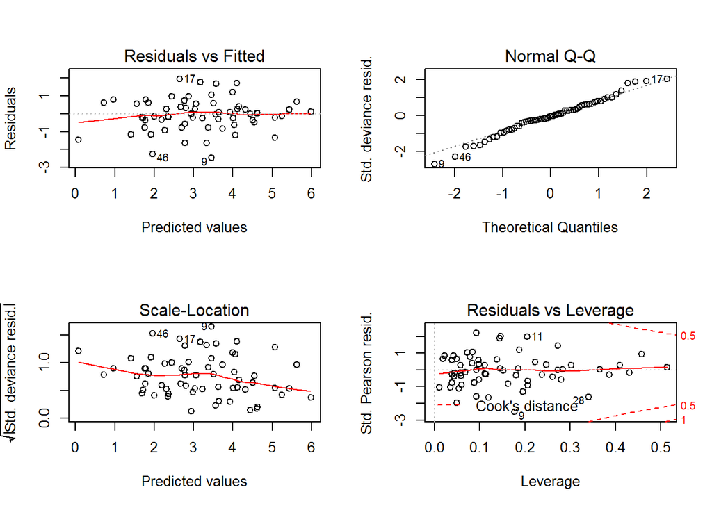

```r
par(mfrow=c(2,2))
plot(mod.poisson)
```

Estem vegent els residus de deviança.

Residus estandaritzats (de Pearson) en el cas de la Poisson.
$$r_i= \frac{Y_i - \lambda_i}{ \sqrt{\lambda_i}}$$

En dades agrupades, quan més agrupades, més fàcil de poder validar el model. En 1 vegem residus al voltant de 0, en 2 que els residus son normals, en 3 considerem que es pràcticament constant (pequè al començament n’hi ha pocs i pot ser per això età una mica més amunt) i en 4 igual. Validem el model.

**Sol: No s’observa cap patró en els gràfics de residus –> Validem el model**

### Validacio: deviança i Pearson

```r
# Per deviança
1 - pchisq(mod.poisson$deviance,mod.poisson$df.residual)
```

```
## [1] 0.5745071
```

No tenim motius per rebutjar la hipòtesis nul·la de que el model ajusta bé les dades.

```r
# Pearson generalitzat
X2P <- sum(resid(mod.poisson,type="pearson")^2);X2P
```

```
## [1] 48.62934
```

```r
1 - pchisq(X2P,mod.poisson$df.residual)
```

```
## [1] 0.6809085
```

- Estadístic: 48.62
- Deviança residual era 51.42

Molt similars, pvalor superior a 0.05 (igual q abans), model bó.

**Sol: Els p-valors surten superiors a 0.05. Usant Dev o X2P no tinc evidència per rebutjar la hipotesi nula: el model ajusta bé les dades. Pero cal que amplii el model? Busco si alguna parella d’interaccions és significativa**

### Interaccions

Mirem si el fet d’introduir interaccions millorem encara mes el model.

```r
mod.poisson1 <- glm(Claims ~ offset(logtamany) + District*Group + Age, family=poisson, data=df)
mod.poisson2 <- glm(Claims ~ offset(logtamany) + District + Group*Age, family=poisson, data=df)
mod.poisson3 <- glm(Claims ~ offset(logtamany) + District*Age + Group, family=poisson, data=df)

Anova(mod.poisson1)
```

```
## Analysis of Deviance Table (Type II tests)
##
## Response: Claims
##                LR Chisq Df Pr(>Chisq)
## District         13.871  3   0.003086 **
## Group            88.667  3  < 2.2e-16 ***
## Age              84.736  3  < 2.2e-16 ***
## District:Group    7.288  9   0.607114
## ---
## Signif. codes:  0 '***' 0.001 '**' 0.01 '*' 0.05 '.' 0.1 ' ' 1
```

```r
Anova(mod.poisson2)
```

```
## Analysis of Deviance Table (Type II tests)
##
## Response: Claims
##           LR Chisq Df Pr(>Chisq)
## District    13.942  3   0.002985 **
## Group       88.667  3  < 2.2e-16 ***
## Age         84.870  3  < 2.2e-16 ***
## Group:Age   10.513  9   0.310599
## ---
## Signif. codes:  0 '***' 0.001 '**' 0.01 '*' 0.05 '.' 0.1 ' ' 1
```

```r
Anova(mod.poisson3) # igual anova(mod.poisson, mod.poisson3, test="Chisq"), només en models en els qe XXX.
```

```
## Analysis of Deviance Table (Type II tests)
##
## Response: Claims
##              LR Chisq Df Pr(>Chisq)
## District       13.871  3   0.003086 **
## Age            84.870  3  < 2.2e-16 ***
## Group          88.757  3  < 2.2e-16 ***
## District:Age    6.561  9   0.682740
## ---
## Signif. codes:  0 '***' 0.001 '**' 0.01 '*' 0.05 '.' 0.1 ' ' 1
```

Cap de les interaccins per sí sola ens resulta significativa, no ens millora el model.

Tenim en compte que al introduir les interaccions gastem 9 graus de llibertat però en cap cas ens redueix la deviança lo suficient com per millorar el model anterior.

**Sol: El model additiu ja sembla prou bo. Cap interaccio surt significativa. Anem a avaluar la sobredispersio**

### Sobredispersio

Com es diagnostica?

1. Estimar parámetre de sobredispersio $\phi$.

```r
# Estimar parámetre de sobredispersio
X2P <- sum(resid(mod.poisson,type="pearson")^2)
phi <- X2P/mod.poisson$df.residual
phi
```

```
## [1] 0.9005432
```

El estadístic de Pearson era 48.62, els graus de llibertat eren 54, per tant un estimació de $\phi$ serà 48.62/54, que es el 0.90 que obtenim amb R.

Al ser inferior a 1, hi ha infradisperssió, la seva variància és més petita del que tocaria.

(pensar en grafica amb eix x com a lambda_i i phi al l’eix y)

2. Proposa com a alternativa al Poission, el model Quasipoisson.

trafo=1: quasipoisson!

$$E(Y|X) = \lambda$$
$$V(Y|X)= (1+\alpha)\lambda$$
El test de sobredispersió que farem contrasta:

$$H_0:\alpha=0 \rightarrow POISSON$$
$$H_1: \alpha>0 \rightarrow SOBREDISPERSSIÓ$$

```r
# Test formal per dependencia lineal amb esperanza
dispersiontest(mod.poisson, trafo = 1)  # V(Y)=(1+alpha)*mu^2 -> Y Quasi-poisson
```

```
##
##  Overdispersion test
##
## data:  mod.poisson
## z = -1.4987, p-value = 0.933
## alternative hypothesis: true alpha is greater than 0
## sample estimates:
##      alpha
## -0.2241824
```

No ens interessa, no és una probaiilitat. Sempre convé fer igualment una Binomial Negativa, que em fa una bona estimaió de alfa.

```r
# Test formal per dependencia quadratica amb esperanza
dispersiontest(mod.poisson, trafo = 2)  # V(Y)=mu+alpha*mu^2 -> Y Bin Neg
```

```
##
##  Overdispersion test
##
## data:  mod.poisson
## z = -1.8988, p-value = 0.9712
## alternative hypothesis: true alpha is greater than 0
## sample estimates:
##       alpha
## -0.00328163
```

**Sol: No hi ha sobredispersió. Poisson funciona bé. No obstant, estimem binomial negativa per verificar-ho.**

# Binomial negativa

Quantes fallides per aconseguir r encerts? trafo=2 $\rightarrow BN(\lambda,\alpha)$
$$E(Y|X) = \lambda$$
$$V(Y|X)= \lambda+\alpha\lambda^2$$

Alfa sempre serà positiva. Per tant la BN només serveix per tracar la sobredispersió. Tot i així, ho aplicarem.

```r
# Estimació theta glm.nb()
mod.nb <- glm.nb(Claims ~ offset(logtamany) + District + Group + Age, data=df)
summary(mod.nb)
```

```
##
## Call:
## glm.nb(formula = Claims ~ offset(logtamany) + District + Group +
##     Age, data = df, init.theta = 449933.9097, link = log)
##
## Deviance Residuals:
##      Min        1Q    Median        3Q       Max
## -2.46551  -0.50795  -0.03196   0.55554   1.94022
##
## Coefficients:
##             Estimate Std. Error z value Pr(>|z|)
## (Intercept) -1.82174    0.07679 -23.723  < 2e-16 ***
## District2    0.02587    0.04302   0.601 0.547637
## District3    0.03853    0.05052   0.763 0.445686
## District4    0.23421    0.06168   3.797 0.000146 ***
## Group1-1.5l  0.16133    0.05054   3.192 0.001412 **
## Group1.5-2l  0.39281    0.05500   7.142 9.23e-13 ***
## Group>2l     0.56341    0.07232   7.791 6.67e-15 ***
## Age25-29    -0.19101    0.08286  -2.305 0.021155 *
## Age30-35    -0.34495    0.08138  -4.239 2.25e-05 ***
## Age>35      -0.53667    0.06996  -7.671 1.70e-14 ***
## ---
## Signif. codes:  0 '***' 0.001 '**' 0.01 '*' 0.05 '.' 0.1 ' ' 1
##
## (Dispersion parameter for Negative Binomial(449933.9) family taken to be 1)
##
##     Null deviance: 236.212  on 63  degrees of freedom
## Residual deviance:  51.416  on 54  degrees of freedom
## AIC: 390.74
##
## Number of Fisher Scoring iterations: 1
##
##
##               Theta:  449934
##           Std. Err.:  4185445
## Warning while fitting theta: iteration limit reached
##
##  2 x log-likelihood:  -368.745
```

```r
# theta = 1/alpha = 449932  tendeix a infinit -> consistent Poisson
```

Primer necessitem el valor de la alfa, per despres podé fer glm() amb famili= binomial negativa de alfa.

El valor que volem es l’invsers del que ens apareix a:*Theta: 449934*

Quan aquest valor és molt alt, és que el que tinc realment és una Poisson. (alfa petita)

```r
# Amb theta per bn -> puc usar metode generic glm()
mod.nb1 <- glm(Claims ~ offset(logtamany) + District + Group + Age, family=neg.bin(449932),data=df)
summary(mod.nb1)
```

```
##
## Call:
## glm(formula = Claims ~ offset(logtamany) + District + Group +
##     Age, family = neg.bin(449932), data = df)
##
## Deviance Residuals:
##      Min        1Q    Median        3Q       Max
## -2.46551  -0.50795  -0.03196   0.55554   1.94022
##
## Coefficients:
##             Estimate Std. Error t value Pr(>|t|)
## (Intercept) -1.82174    0.07287 -25.000  < 2e-16 ***
## District2    0.02587    0.04083   0.634 0.528976
## District3    0.03853    0.04794   0.804 0.425114
## District4    0.23421    0.05853   4.002 0.000193 ***
## Group1-1.5l  0.16133    0.04796   3.364 0.001419 **
## Group1.5-2l  0.39281    0.05219   7.526 5.77e-10 ***
## Group>2l     0.56341    0.06863   8.210 4.53e-11 ***
## Age25-29    -0.19101    0.07863  -2.429 0.018487 *
## Age30-35    -0.34495    0.07722  -4.467 4.09e-05 ***
## Age>35      -0.53667    0.06639  -8.084 7.22e-11 ***
## ---
## Signif. codes:  0 '***' 0.001 '**' 0.01 '*' 0.05 '.' 0.1 ' ' 1
##
## (Dispersion parameter for Negative Binomial family taken to be 0.9004763)
##
##     Null deviance: 236.212  on 63  degrees of freedom
## Residual deviance:  51.416  on 54  degrees of freedom
## AIC: 388.74
##
## Number of Fisher Scoring iterations: 4
```

```r
# Comparacio amb Poisson
anova(mod.poisson, mod.nb1, test="LRT")
```

```
## Analysis of Deviance Table
##
## Model 1: Claims ~ offset(logtamany) + District + Group + Age
## Model 2: Claims ~ offset(logtamany) + District + Group + Age
##   Resid. Df Resid. Dev Df  Deviance Pr(>Chi)
## 1        54     51.420
## 2        54     51.416  0 0.0035771
```

**Sol: deviances practicament identiques ente Poisson i binomial negativa (p-valor no es estimable–> mateix numero de parametres)**

# Interpretacio coeficients en model de Poisson

```r
co <- cbind(coef(mod.poisson),confint(mod.poisson))
round(exp(co),2)
```

```
##                  2.5 % 97.5 %
## (Intercept) 0.16  0.14   0.19
## District2   1.03  0.94   1.12
## District3   1.04  0.94   1.15
## District4   1.26  1.12   1.42
## Group1-1.5l 1.18  1.07   1.30
## Group1.5-2l 1.48  1.33   1.65
## Group>2l    1.76  1.52   2.02
## Age25-29    0.83  0.70   0.97
## Age30-35    0.71  0.60   0.83
## Age>35      0.58  0.51   0.67
```

1.26: un 26% d’increment.